# Relacion precio medio (PM) y tipo de produccion

# 3. Analisis bivarial precio medio y tipo de produccion

# Nota: los resultados corresponden al apartado 2.5

# 3.1.Analisis correlaciones precio - produccion

```r
#Analisis de correlaciones entre la variable precio medio y el tipo de produccion
t3<-electricity_prices[,c("PM", "eol", "nuc", "hid", "cco", "sol")]
#Eliminamos observaciones sin datos (NAs)
t3.na<-t3[!is.na(t3$hid),]
t3.na<-t3.na[!is.na(t3.na$sol),]
cort3<-cor(t3.na)
round(cort3,4)
```

```
         PM     eol     nuc     hid    cco     sol
PM   1.0000 -0.4985 -0.0872 -0.3463 0.0090  0.0974
eol -0.4985  1.0000  0.0328  0.3165 0.0338 -0.1694
nuc -0.0872  0.0328  1.0000  0.0741 0.1714 -0.0254
hid -0.3463  0.3165  0.0741  1.0000 0.0355 -0.1691
cco  0.0090  0.0338  0.1714  0.0355 1.0000  0.0640
sol  0.0974 -0.1694 -0.0254 -0.1691 0.0640  1.0000
```

La correlacion mas alta se encuentra entre PM, produccion eolica (-0.4985) y produccion hidraulica (-0.3463), negativa en ambos casos. Por lo tanto este tipo de produccion contribuye a la disminucion del precio.

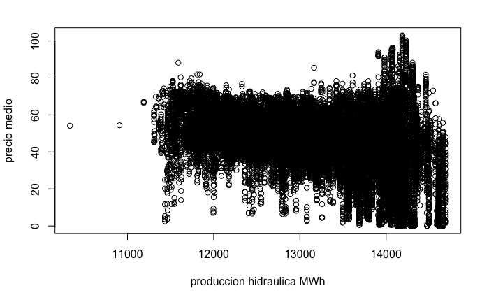

```r
#Analisis precio- energia hidraulica
plot(electricity_prices$hid, PM, xlab="produccion hidraulica MWh", ylab="precio medio")
```

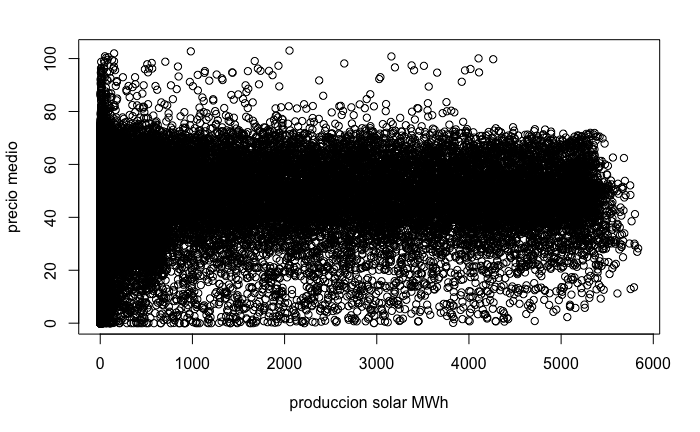

```r
#Analisis precio- solar
plot(electricity_prices$sol, PM, xlab="produccion solar MWh", ylab="precio medio")
```

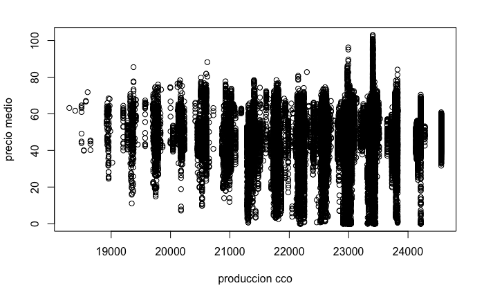

```r
#Analisis precio- energia hidraulica
plot(electricity_prices$cco, PM, xlab="produccion cco", ylab="precio medio")
```

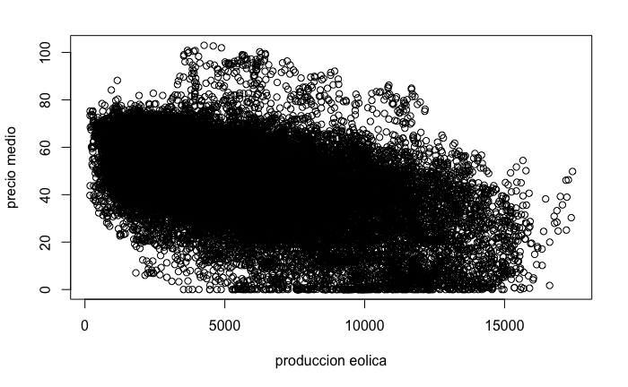

```r
#Analisis precio- energia eolica
plot(electricity_prices$eol, PM, xlab="produccion eolica", ylab="precio medio")
```

# 3.1.1 Regresion precio energia eolica

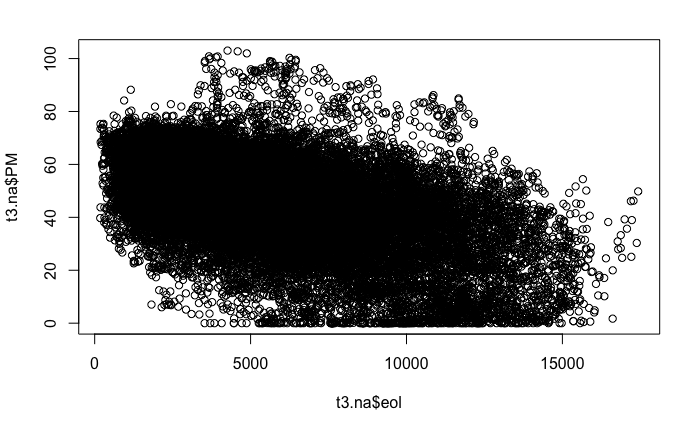

```r
#Analisis relacion PM - produccion eolica
plot(t3.na$eol, t3.na$PM)
```

```r
#Realizamos regresion y comprobamos la normalidad
eol_p.lm = lm(t3.na$PM ~ t3.na$eol  , data=t3.na)
eol_p.lm
```

```
Call:
lm(formula = t3.na$PM ~ t3.na$eol, data = t3.na)

Coefficients:
(Intercept)    t3.na$eol
  58.278927    -0.002419
```

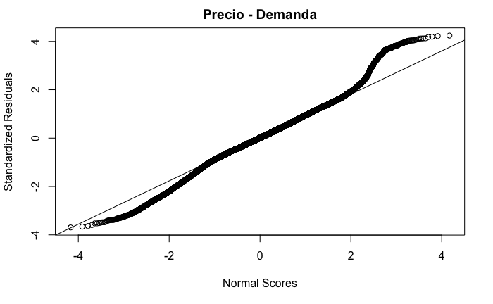

```r
eol_p.stdres = rstandard(eol_p.lm)
qqnorm(eol_p.stdres,
       ylab="Standardized Residuals",
       xlab="Normal Scores",
       main="Precio - Demanda")
qqline(eol_p.stdres)
```

```r
summary(eol_p.lm)
```

```
Call:
lm(formula = t3.na$PM ~ t3.na$eol, data = t3.na)

Residuals:
    Min      1Q  Median      3Q     Max
-49.749  -7.836   0.128   8.435  57.108

Coefficients:
              Estimate Std. Error t value Pr(>|t|)
(Intercept)  5.828e+01  1.481e-01   393.5   <2e-16 ***
t3.na$eol   -2.419e-03  2.322e-05  -104.2   <2e-16 ***
---
Signif. codes:  0 '***' 0.001 '**' 0.01 '*' 0.05 '.' 0.1 ' ' 1

Residual standard error: 13.47 on 32828 degrees of freedom
Multiple R-squared:  0.2485,    Adjusted R-squared:  0.2485
F-statistic: 1.086e+04 on 1 and 32828 DF,  p-value: < 2.2e-16
```

El valor de R-squared es muy bajo (0.2485), lo que demuestra la poca relacion lineal entre las variables.

```r
#A??adimos la linea de regresion al grafico
R_squared<-0.2485
plot(t3.na$eol, t3.na$PM, xlab = "produccion eolica MWh", ylab = "precio medio")
abline(lm(t3.na$PM ~ t3.na$eol), col= "red")
```

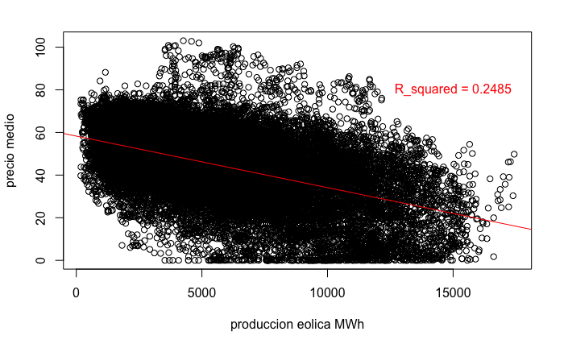

```r
text(15000, 80, labels = "R_squared = 0.2485", col = "red")
```

# 3.1.Analisis correlaciones demanda - produccion

```r
#Analisis de correlaciones entre la variable demanda y la produccion
t4<-electricity_prices[,c("dem", "eol", "nuc", "hid", "cco", "sol")]
#Eliminamos observaciones sin datos (NAs)
t4.na<-t4[!is.na(t4$hid),]
t4.na<-t4.na[!is.na(t4.na$sol),]
cor(t4.na)
```

```
           dem         eol         nuc         hid        cco         sol
dem 1.00000000  0.05565631  0.07754954  0.03771741 0.17305021  0.39547658
eol 0.05565631  1.00000000  0.03278270  0.31650403 0.03375717 -0.16935923
nuc 0.07754954  0.03278270  1.00000000  0.07408872 0.17138443 -0.02537330
hid 0.03771741  0.31650403  0.07408872  1.00000000 0.03548102 -0.16908059
cco 0.17305021  0.03375717  0.17138443  0.03548102 1.00000000  0.06401432
sol 0.39547658 -0.16935923 -0.02537330 -0.16908059 0.06401432  1.00000000
```

Observamos que no existen correlaciones significativas entre la demanda y el tipo de produccion, lo que hace pensar que la demanda no afecta al tipo de produccion (es decir, no parecen utilizarse fuentes concretas para cubrir los picos en la demanda). La correlacion mas elevada es entre demanda y produccion solar (0.396).

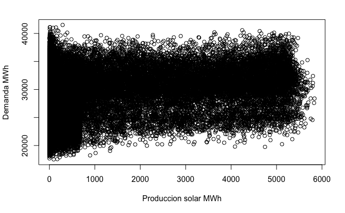

```r
#Analisis relacion demanda produccion solar
plot(t4.na$sol, t4.na$dem, ylab= "Demanda MWh", xlab="Produccion solar MWh")
```

```r
#Realizamos regresion
sol_d.lm = lm(t4.na$dem ~ t4.na$sol  , data=t4.na)
summary(sol_d.lm)
```

```
Call:
lm(formula = t4.na$dem ~ t4.na$sol, data = t4.na)

Residuals:
     Min       1Q   Median       3Q      Max
-12105.9  -3300.3   -187.9   2931.4  14402.3

Coefficients:
             Estimate Std. Error t value Pr(>|t|)
(Intercept) 2.680e+04  3.074e+01  871.86   <2e-16 ***
t4.na$sol   1.066e+00  1.367e-02   78.01   <2e-16 ***
---
Signif. codes:  0 '***' 0.001 '**' 0.01 '*' 0.05 '.' 0.1 ' ' 1

Residual standard error: 4193 on 32828 degrees of freedom
Multiple R-squared:  0.1564,    Adjusted R-squared:  0.1564
F-statistic:  6086 on 1 and 32828 DF,  p-value: < 2.2e-16
```

El valore de R-squared (0.16) es muy bajo, por lo tanto esta linea no explica gran parte de la varianza.